# Has the Money Come in for the Democrats?

Luke Killoran

*Before using the code, download and unzip the candidate summary file for the 2016 campaign from this address: https://www.kaggle.com/danerbland/electionfinance.Do the same for the 2018 campaign through this link: https://classic.fec.gov/data/CandidateSummary.do?format=html. (Use the csv button.) Then move both files into your working directory.*

*Note that the file descriptions are provided [here](https://classic.fec.gov/finance/disclosure/metadata/metadataforcandidatesummary.shtml) and [here](https://classic.fec.gov/data/CandidateSummary.do?format=html) respectively.*

*This document is unfinished.*

This document has two motivations: 1. Find out whether the Democrats really have received more funding than they did in 2016 2. Make a(n) (explainable) miniature model (based solely on contributions and incumbency status) to investigate the chances that the Democrats take the House

First, some plots to illustrate how Democrats’ coffers are brimming.

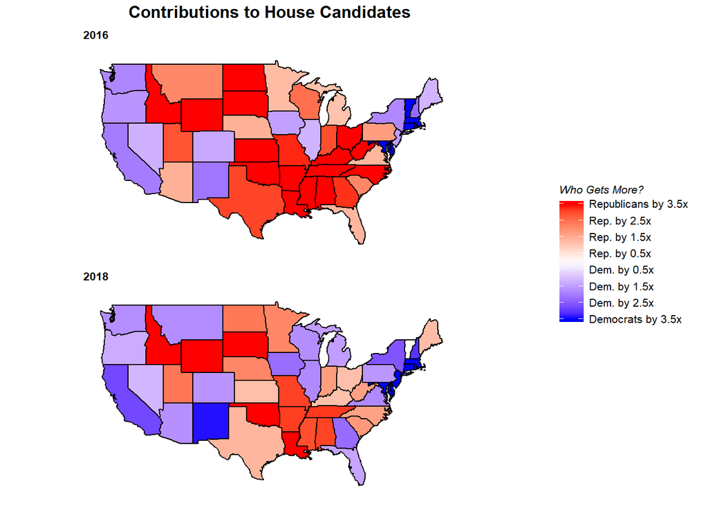

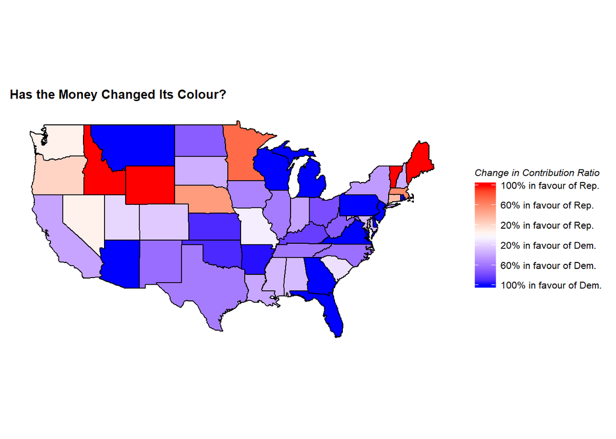

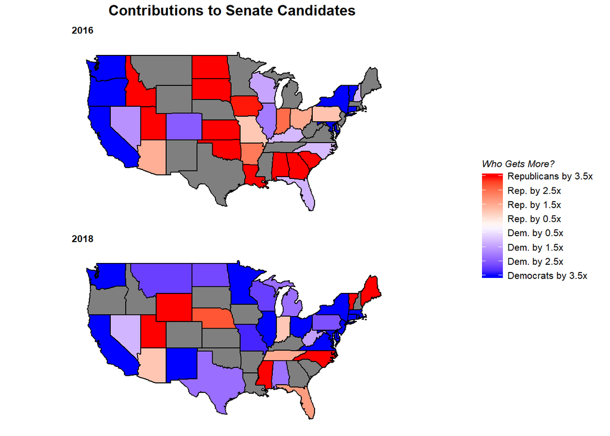

The chart below exhibits the landscape of the current state of play.

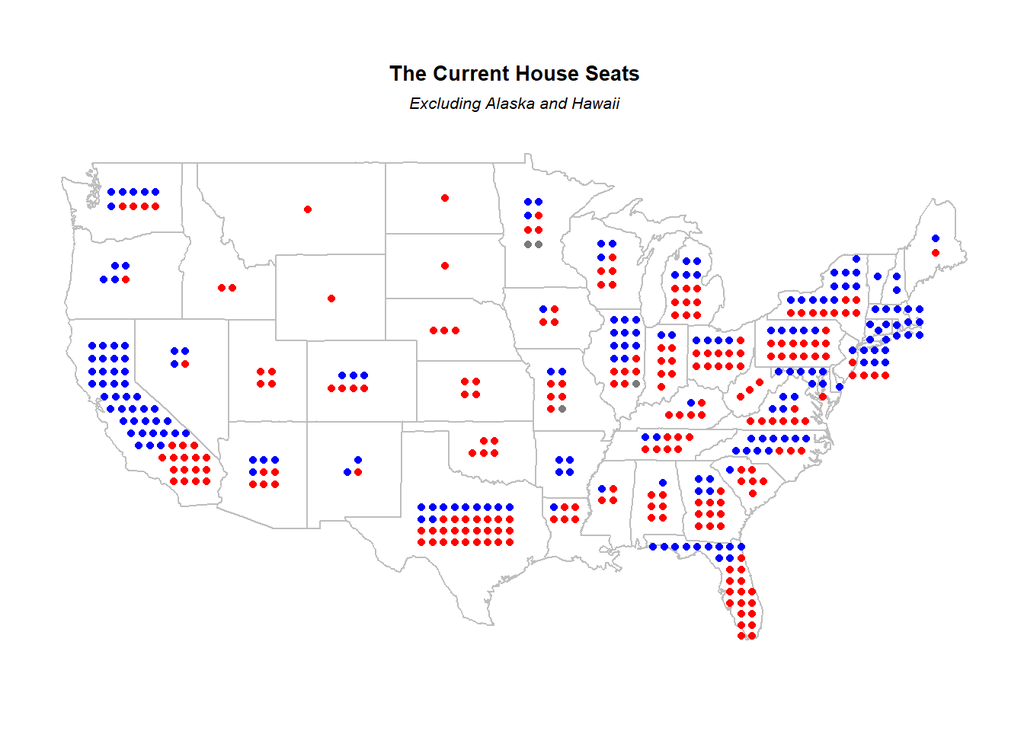